# Tudor England Urban Scaling

Part 1 - Data Quality Checks

Rudolf Cesaretti

2019-08-09

Please direct any questions and comments to Rudolf Cesaretti (rcesaret@asu.edu)

Analyses in this ‘Data Replication’ script were performed in R versions 3.4.3 (2017-11-30) and 3.6.0 (2019-04-26). R-Studio is ideal for viewing and manipulating this file.

The subsections of this script, indicated by triple-pound-sign comment lines, specify which subsections they correspond to in the main text (e.g. “4.1 Data Quality”) and in the online Appendix (e.g. “A1.1 Distributional Analysis”)

The additional R packages required in each section are indicated at the top of each section. To download the requisite packages to your library, simply un-comment-out the function “install.packages()”, and make sure you have a secure connection to the internet.

This file requires that the working-directory be set to a local folder that includes “main_dataset.csv”, “add_taxpayers.csv”, “WCS.csv”, “resid_coords_geog.csv”, and “TudorCounties.csv” which are included in the online supplementary materials

Commands to export figures (as .tif files) and tables (as .csv files) have also been commented-out

## Preliminaries

### Load Custom R Functions

```r
#Read in custom R functions located in the WD$R directory folder

# Custom function R file names
functions <- c("ks_test_tidy.R", "histogram_density.R",
               "plot_ks_ci.R", "gg_histogram_density.R",
               "ggplot_ks_ci.R")

invisible(lapply(functions, function(filename) {
  source(file.path("R", filename))
}))

rm(functions) # Remove the vector of function filenames from the environment
```

### Load Required Packages

```r
# Load required packages
library(MASS)
library(NSM3)
library(gt)
library(dplyr)
library(ggplot2)
```

### Load Data

```r
# Upload datasets from working directory
main_dataset <- read.csv(file = "data/raw/main_dataset.csv", header=TRUE, sep=",")

add_taxpayers <- read.csv(file = "data/raw/add_taxpayers.csv", header=TRUE, sep=",")
```

## 4.1 Data Quality and A1.1 Distributional Analysis

#### Figure A1: Histograms of the Lay Subsidy data (n = 93)

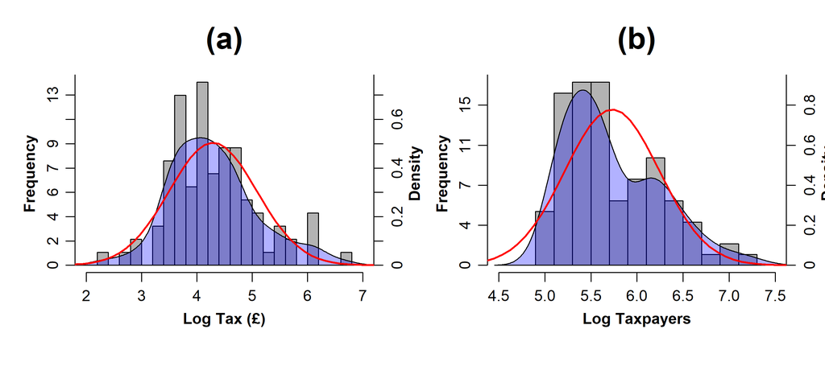

```r
ks_test_tidy(data = main_dataset, columns = c("Log_Tax", "Log_Taxpayers"),
             output = "gt", dist = "normal", alpha = 0.05, signif_digits = 3) %>%
  tab_header(
    title = "Table 1. Asymptotic One-Sample Kolmogorov-Smirnov Normality Test for Log Tax and Log Taxpayers (n = 93)"
  )
```

Table 1. Asymptotic One-Sample Kolmogorov-Smirnov Normality Test for Log Tax and Log Taxpayers (n = 93)

| Variable | Sample Size | Distribution | D Statistic | P-Value | Alpha | Alternative Hypothesis | Result |
| --- | --- | --- | --- | --- | --- | --- | --- |
| Log_Tax | 93 | Gaussian | 0.080 | 0.594 | 0.05 | Two-sided | Fail to Reject |
| Log_Taxpayers | 93 | Gaussian | 0.137 | 0.060 | 0.05 | Two-sided | Fail to Reject |

#### Figure A2: Kolmogorov-Smirnov Test Plots with 95% C.I.s

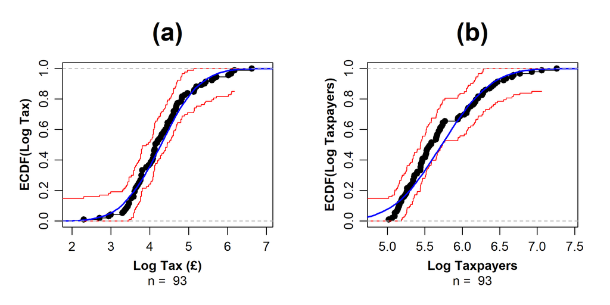

#### Figure A3: Zipfian Tail of Taxpayer Count Log-Log Rank-Size Plot

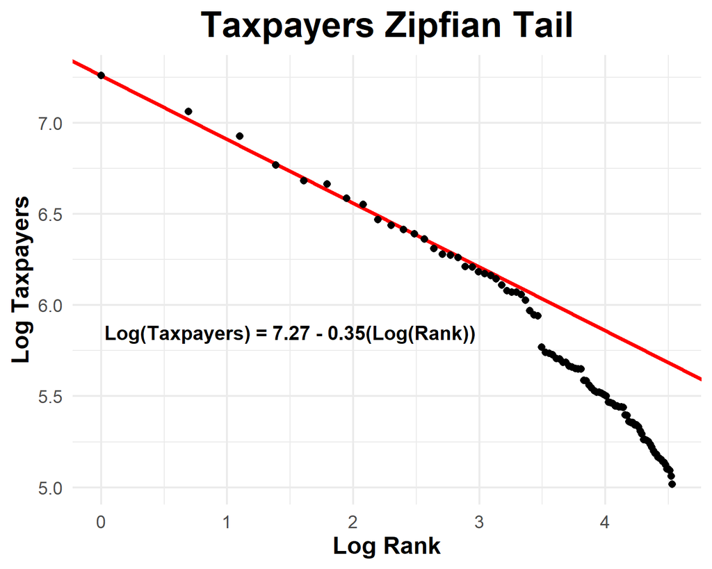

#### Figure A4: Analysis of the Expanded 1524/5 Lay Subsidy Taxpayer Counts Dataset (expanded sample of towns with at least 50 taxpayers)

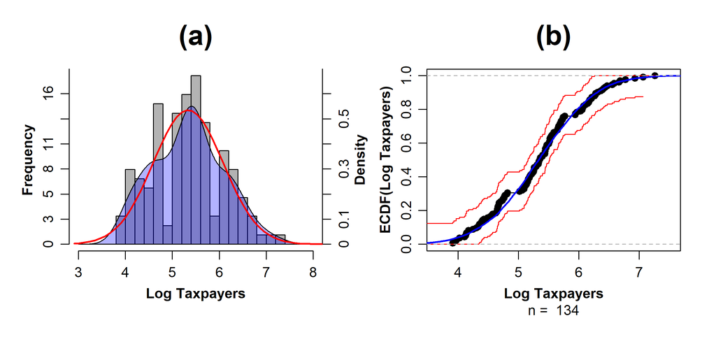

Kolmogorov-Smirnov test for Log Taxpayers (n = 134) using expanded sample of towns with at least 50 taxpayers

```r
ks_test_tidy(data = add_taxpayers, columns = "Log_Taxpayers", output = "gt",
             dist = "normal", alpha = 0.05, signif_digits = 3) %>%
  tab_header(
    title = "Table 2. Asymptotic One-Sample Kolmogorov-Smirnov Normality Test",
    subtitle = "For Log Taxpayers using the expanded sample of towns with at least 50 taxpayers (n = 134)"
  )
```

Table 2. Asymptotic One-Sample Kolmogorov-Smirnov Normality Test

For Log Taxpayers using the expanded sample of towns with at least 50 taxpayers (n = 134)

| Variable | Sample Size | Distribution | D Statistic | P-Value | Alpha | Alternative Hypothesis | Result |
| --- | --- | --- | --- | --- | --- | --- | --- |
| Log_Taxpayers | 134 | Gaussian | 0.063 | 0.655 | 0.05 | Two-sided | Fail to Reject |